# 聚类分析

## 2.2 层次聚类

要在R中建立层次聚类模型，可以使用stats包中的hclust()函数。这个函数需要两个基本输 入:距离矩阵和聚类方法。使用dist()函数可以轻松生成距离矩阵，我们使用的是欧氏距离。 可以使用的聚类方法有若干种，hclust()函数使用的默认方法是最大距离法

在R中，我们可以使用NbClust包中的NbClust()函数，求出23种聚类有效性指标的结果，包 括Miligan和Cooper论文中最好的5种和gap统计量

使用这个函数时，你需要指定簇的最小值和最大值、距离类型、测距方式和有效性指标。在以下的代码中可以看到，我们要建立一个名 为numComplete的对象，函数指定使用欧氏距离，簇的最小数量为2，最大数量为6，测距方式为 最大距离法，并使用所有有效性指标。

Hubert指数图: 在左侧的图中，你要找出一 个明显的拐点;在右侧的图中，你要找到峰值.左图在3个簇的地方有个拐点，右图在3个簇的时候达到峰值

Dindex图:提供了同样的信息

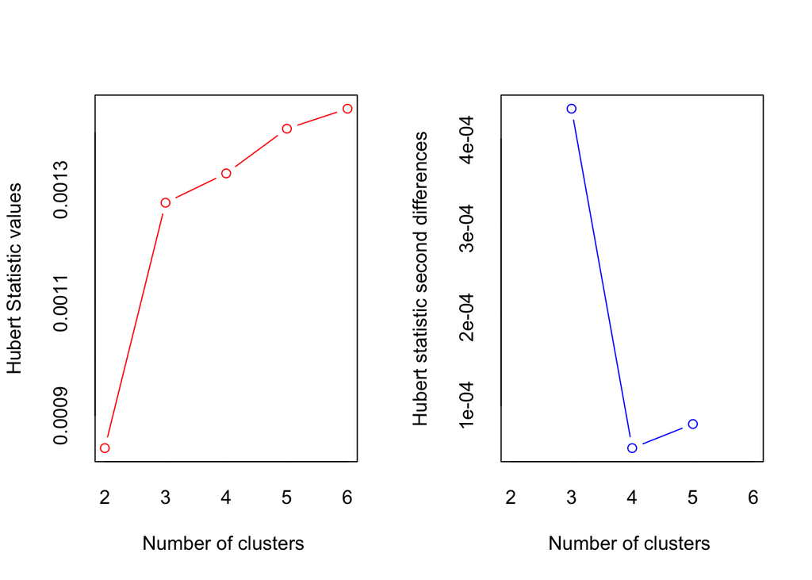

```
## *** : The Hubert index is a graphical method of determining the number of clusters.
##                 In the plot of Hubert index, we seek a significant knee that corresponds to a
##                 significant increase of the value of the measure i.e the significant peak in Hubert
##                 index second differences plot.
##
```

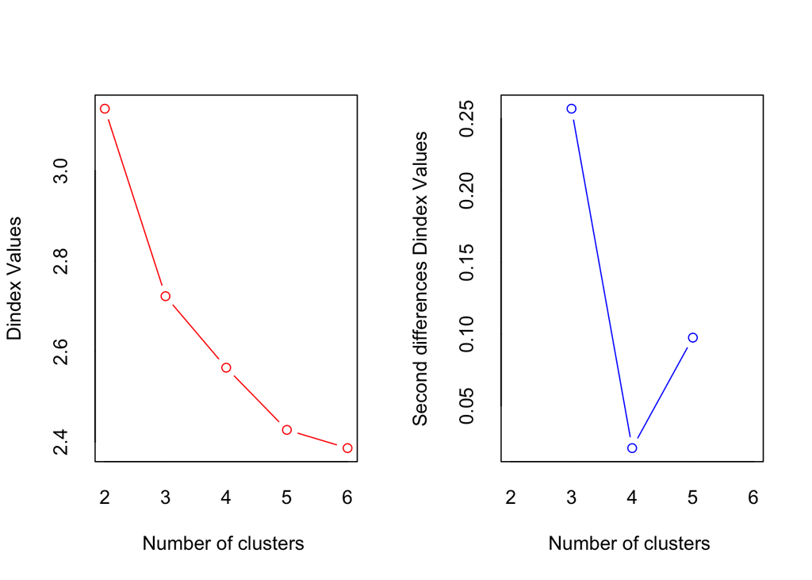

```
## *** : The D index is a graphical method of determining the number of clusters.
##                 In the plot of D index, we seek a significant knee (the significant peak in Dindex
##                 second differences plot) that corresponds to a significant increase of the value of
##                 the measure.
##
## * Among all indices:
## * 1 proposed 2 as the best number of clusters
## * 11 proposed 3 as the best number of clusters
## * 6 proposed 5 as the best number of clusters
## * 5 proposed 6 as the best number of clusters
##
##                    ***** Conclusion *****
##
## * According to the majority rule, the best number of clusters is  3
##
##
```

```r
numComplete <- NbClust(df, distance = "euclidean",
                       min.nc = 2, max.nc = 6,
                       method = "complete", index = "all")
```

```r
## 每种有效性指标的最优簇数 量和与之对应的指标值
## 第一个指标(KL)的最优簇数量是5，第二个指标(CH)的最优簇数量是3
numComplete$Best.nc
```

```
##                      KL      CH Hartigan   CCC    Scott      Marriot   TrCovW
## Number_clusters  5.0000  3.0000   3.0000 5.000   3.0000 3.000000e+00     3.00
## Value_Index     14.2227 48.9898  27.8971 1.148 340.9634 6.872632e+25 22389.83
##                   TraceW Friedman   Rubin Cindex     DB Silhouette   Duda
## Number_clusters   3.0000   3.0000  5.0000 3.0000 6.0000     3.0000 5.0000
## Value_Index     256.4861  10.6941 -0.1489 0.3551 1.6018     0.2038 0.8856
##                 PseudoT2  Beale Ratkowsky     Ball PtBiserial Frey McClain
## Number_clusters   5.0000 5.0000    3.0000   3.0000     6.0000    1  2.0000
## Value_Index       6.3314 1.1253    0.3318 462.0304     0.5877   NA  0.7687
##                   Dunn Hubert SDindex Dindex   SDbw
## Number_clusters 6.0000      0  6.0000      0 6.0000
## Value_Index     0.1892      0  0.9951      0 0.5031
```

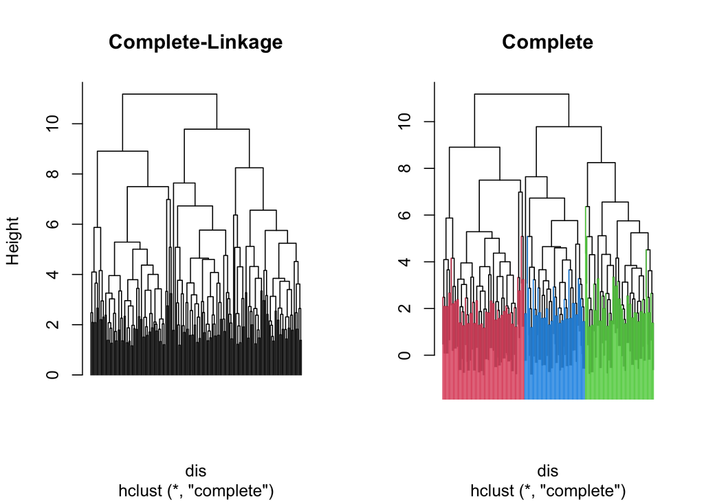

```r
## 选择3个簇进行聚类，现在计算距离矩阵，并建立层次聚类模型
dis <- dist(df, method = "euclidean")
hc <- hclust(dis, method = "complete")

## 可视化的通用方式是画出树状图，可以用plot函数实现。注意，参数hang=-1表示 将观测排列在图的底部
## 树状图表明了观测是如何聚集的，图中的连接(也可称为分支)告诉我们哪些观测是相 似的。分支的高度表示观测之间相似或相异的程度
plot(hc, hang = -1,labels = FALSE, main = "Complete-Linkage")

## 想使聚类可视化效果更好，可以使用sparcl包生成彩色树状图。要对合适数目的簇上色， 需要使用cutree()函数对树状图进行剪枝，以得到合适的簇的数目。这个函数还可以为每个观 测生成簇标号:
comp3 <- cutree(hc, 3)
ColorDendrogram(hc, y = comp3, main = "Complete", branchlength = 50)
```

```r
## 我指定了参数branchlength=50，这个值要根据你自己的数据确定。因为我们已 经有了簇标号，所以可以建立一个表格查看每个簇中观测的数量
table(comp3)
```

```
## comp3
##  1  2  3
## 69 58 51
```

```r
table(comp3, wine$Class)
```

```
##
## comp3  1  2  3
##     1 51 18  0
##     2  8 50  0
##     3  0  3 48
```

```r
## 行是簇标号，列是品种等级标号。聚类结果匹配了84%的品种等级
(51+50+48)/178
```

```
## [1] 0.8370787
```

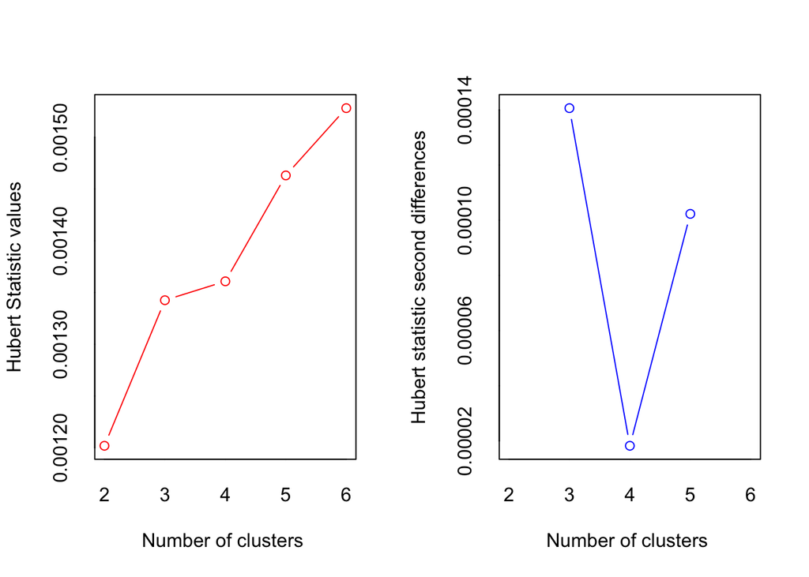

```
## *** : The Hubert index is a graphical method of determining the number of clusters.
##                 In the plot of Hubert index, we seek a significant knee that corresponds to a
##                 significant increase of the value of the measure i.e the significant peak in Hubert
##                 index second differences plot.
##
```

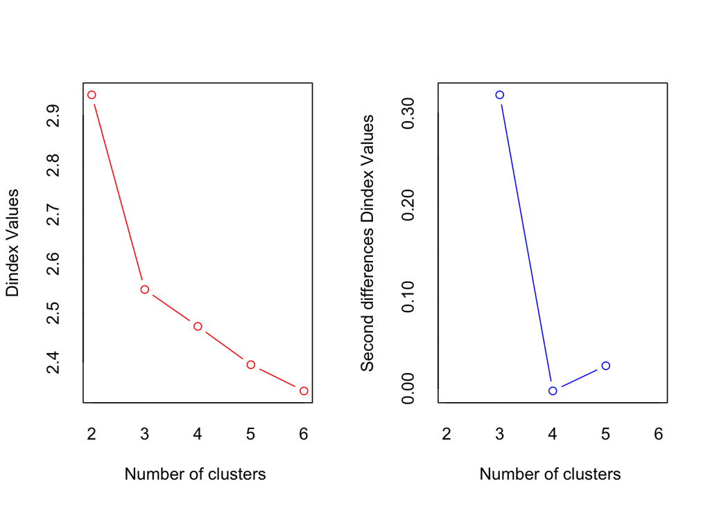

```
## *** : The D index is a graphical method of determining the number of clusters.
##                 In the plot of D index, we seek a significant knee (the significant peak in Dindex
##                 second differences plot) that corresponds to a significant increase of the value of
##                 the measure.
##
## * Among all indices:
## * 2 proposed 2 as the best number of clusters
## * 18 proposed 3 as the best number of clusters
## * 2 proposed 6 as the best number of clusters
##
##                    ***** Conclusion *****
##
## * According to the majority rule, the best number of clusters is  3
##
##
```

```r
## Ward距离法。代码和前面的一样，首先确定簇的数目，应该将method的值改为 Ward.D2
numWard <- NbClust(df, diss = NULL, distance = "euclidean",
        min.nc = 2,
        max.nc = 6,
        method= "ward.D2",
        index = "all")
```

```r
hcWard <- hclust(dis, method = "ward.D2")
plot(hcWard, hang = -1, labels = FALSE, main = "Ward's-Linkage")

## 图中显示的3个簇区别十分明显，每个簇中观测的数量大致相同。计算每个簇的大小，并与 品种等级标号进行比较
ward3 <- cutree(hcWard, 3)
table(ward3, wine$Class)
```

```
##
## ward3  1  2  3
##     1 59  5  0
##     2  0 58  0
##     3  0  8 48
```

```r
## 另一个表比较两种方法的观测匹配情况
table(comp3, ward3)
```

```
##      ward3
## comp3  1  2  3
##     1 53 11  5
##     2 11 47  0
##     3  0  0 51
```

[figure not shown]

```r
## 箱线图可以很好地比较变量的分布，它可以展示最小值、第一四分位数、中位数、第三四分 位数、最大值和可能的离群点
par(mfrow = c(1, 2))
```

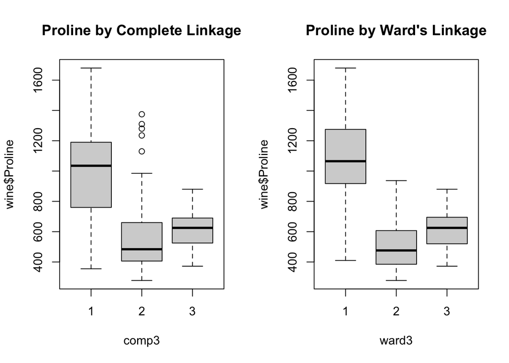

```r
boxplot(wine$Proline ~ comp3,
        main = "Proline by Complete Linkage")
boxplot(wine$Proline ~ ward3,
        main = "Proline by Ward's Linkage")
```

```r
## Ward距离法中 的第一个和第二个簇具有更紧凑的四分位距，没有疑似离群点
```

## 2.3 K 均值聚类

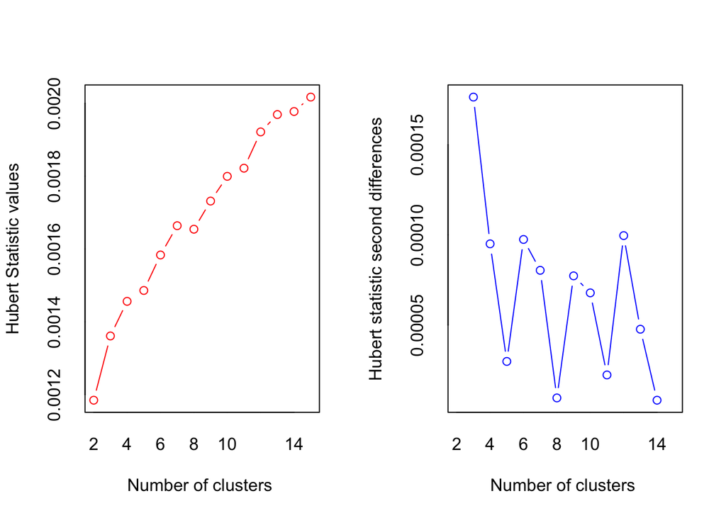

```
## *** : The Hubert index is a graphical method of determining the number of clusters.
##                 In the plot of Hubert index, we seek a significant knee that corresponds to a
##                 significant increase of the value of the measure i.e the significant peak in Hubert
##                 index second differences plot.
##
```

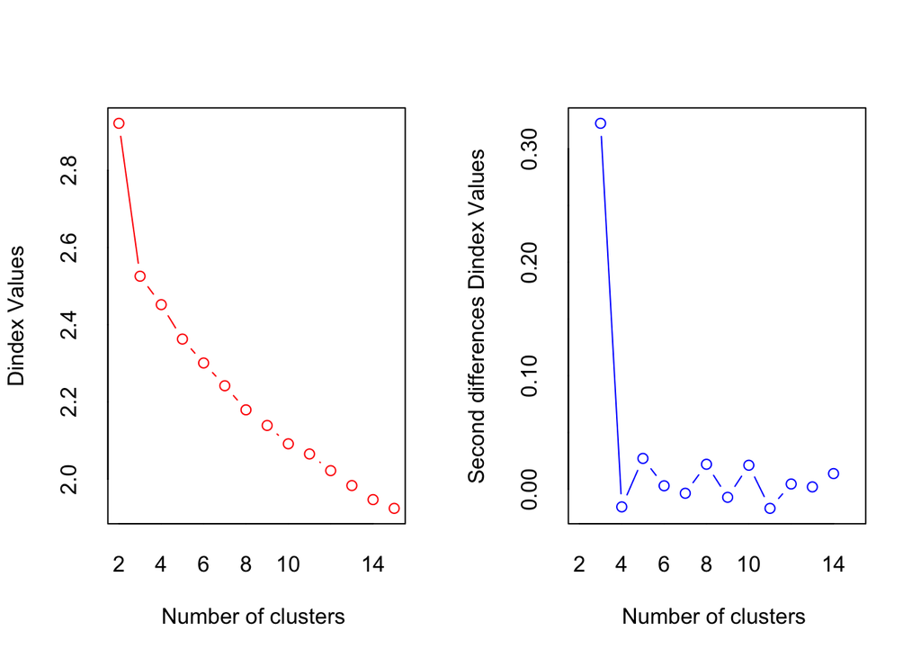

```
## *** : The D index is a graphical method of determining the number of clusters.
##                 In the plot of D index, we seek a significant knee (the significant peak in Dindex
##                 second differences plot) that corresponds to a significant increase of the value of
##                 the measure.
##
## * Among all indices:
## * 2 proposed 2 as the best number of clusters
## * 19 proposed 3 as the best number of clusters
## * 1 proposed 14 as the best number of clusters
## * 1 proposed 15 as the best number of clusters
##
##                    ***** Conclusion *****
##
## * According to the majority rule, the best number of clusters is  3
##
##
```

```r
## 函数中将method的值设定为kmeans即可，同时将最大簇数目放大到15
numKMeans <- NbClust(df, min.nc = 2, max.nc = 15, method = "kmeans")
```

```r
## 3个簇再次成为最优解
set.seed(1234)
km <- kmeans(df, 3, nstart = 25)
table(km$cluster)
```

```
##
##  1  2  3
## 62 65 51
```

```r
## 簇之间的观测数量分布得非常均衡。我曾经不止一次遇到过这种情况，在一个有很多变量的 大数据集中，不管使用多少个簇的K均值聚类，都得不到有价值且令人信服的结果。对聚类结果 的另一种分析方式是查看簇中心点矩阵，它保存了每个簇中每个变量的中心点值:
km$centers
```

```
##      Alcohol  MalicAcid        Ash    Alk_ash   magnesium   T_phenols
## 1  0.8328826 -0.3029551  0.3636801 -0.6084749  0.57596208  0.88274724
## 2 -0.9234669 -0.3929331 -0.4931257  0.1701220 -0.49032869 -0.07576891
## 3  0.1644436  0.8690954  0.1863726  0.5228924 -0.07526047 -0.97657548
##    Flavanoids    Non_flav    Proantho C_Intensity        Hue  OD280_315
## 1  0.97506900 -0.56050853  0.57865427   0.1705823  0.4726504  0.7770551
## 2  0.02075402 -0.03343924  0.05810161  -0.8993770  0.4605046  0.2700025
## 3 -1.21182921  0.72402116 -0.77751312   0.9388902 -1.1615122 -1.2887761
##      Proline
## 1  1.1220202
## 2 -0.7517257
## 3 -0.4059428
```

## 2.4 果瓦系数和PAM

```r
## 处理因子变量，所以可以将酒 精函数转换为因子，它有两个水平:高/低
wine$Alcohol <- as.factor(ifelse(df$Alcohol > 0, "High", "Low"))
## 建立相异度矩阵，使用cluster包中的daisy()函数
disMatrix <- daisy(wine[, -1], metric = "gower")
set.seed(123)
pamFit <- pam(disMatrix, k = 3)
table(pamFit$clustering)
```

```
##
##  1  2  3
## 62 71 45
```

```r
table(pamFit$clustering, wine$Class)
```

```
##
##      1  2  3
##   1 57  5  0
##   2  2 64  5
##   3  0  2 43
```

```r
wine$cluster <- pamFit$clustering


## 使用compareGroups包建立一张描述性统计表
group <- compareGroups(cluster ~ ., data = wine)
clustab <- createTable(group)
clustab
```

```
##
## --------Summary descriptives table by 'cluster'---------
##
## _________________________________________________________
##                  1           2           3      p.overall
##                N=62        N=71        N=45
## ¯¯¯¯¯¯¯¯¯¯¯¯¯¯¯¯¯¯¯¯¯¯¯¯¯¯¯¯¯¯¯¯¯¯¯¯¯¯¯¯¯¯¯¯¯¯¯¯¯¯¯¯¯¯¯¯¯
## Class       1.08 (0.27) 2.04 (0.31) 2.96 (0.21)  <0.001
## Alcohol:                                         <0.001
##     High     62 (100%)   1 (1.41%)  29 (64.4%)
##     Low      0 (0.00%)  70 (98.6%)  16 (35.6%)
## MalicAcid   2.00 (0.83) 1.95 (0.91) 3.41 (1.09)  <0.001
## Ash         2.42 (0.27) 2.28 (0.30) 2.44 (0.18)   0.002
## Alk_ash     17.2 (2.75) 20.2 (3.20) 21.6 (2.26)  <0.001
## magnesium   105 (11.7)  95.6 (16.8) 99.1 (10.8)   0.001
## T_phenols   2.83 (0.36) 2.20 (0.56) 1.71 (0.37)  <0.001
## Flavanoids  2.96 (0.42) 1.99 (0.76) 0.81 (0.31)  <0.001
## Non_flav    0.29 (0.07) 0.36 (0.12) 0.46 (0.12)  <0.001
## Proantho    1.89 (0.43) 1.60 (0.60) 1.18 (0.43)  <0.001
## C_Intensity 5.44 (1.29) 3.17 (1.01) 7.51 (2.36)  <0.001
## Hue         1.07 (0.13) 1.03 (0.21) 0.69 (0.13)  <0.001
## OD280_315   3.12 (0.36) 2.75 (0.58) 1.70 (0.26)  <0.001
## Proline     1070 (279)   535 (167)   635 (119)   <0.001
## ¯¯¯¯¯¯¯¯¯¯¯¯¯¯¯¯¯¯¯¯¯¯¯¯¯¯¯¯¯¯¯¯¯¯¯¯¯¯¯¯¯¯¯¯¯¯¯¯¯¯¯¯¯¯¯¯¯
```

```r
# export2csv(clustab,file = "wine_clusters.csv")
# export2pdf(clustab, file = "wine_clusters.pdf")
```